# Survival Theory Course

Frailty

Andrea Discacciati

# Frailty and proportional fraily model

A *frailty* is a latent random variable $Z$ that captures heterogeneity in a population.

In the univariate frailty model (at most one event per individual), the hazard rate of an individual is given as the product of an individual specific frailty $Z$ and a basic rate $\alpha(t)$, such that

$$\begin{align*}
\alpha(t|Z) &= Z\alpha(t)
\end{align*}$$

Note that $Z$ and $\alpha(t)$ are *not* observable. What may be observed in a population is not the individual hazard rates $\alpha(t|Z)$, but the net result for a number of individuals with differing frailties, or what we term the *population hazard rate*.

# Population survival

Given $Z$, (conditional) survival to time $t$ is given by

$$\begin{align*}
S(t|Z) &= \exp\left(-Z\int_0^t \alpha(u) du\right) \\
&= \exp(-Z A(t))
\end{align*}$$

where $A(t)$ is the cumulative hazard.

The *population survival function* is found by integrating $S(t|Z)$ over the distribution of $Z$, such that

$$\begin{align*}
S(t) &= \int_0^\infty f_Z(z) \exp(-zA(t)) dz \\ &= E_Z\left(\exp(-ZA(t))\right)
\end{align*}$$

$S(t)$ has a population averaged interpretation. If there are no covariates, $S(t)$ may be seen as a weighted average of individual survival curves, where the weighing depends on the distribution of $Z$.

# Population hazard

It is useful to introduce the *Laplace transform* of $Z$, defined by

$$\begin{align*}
\mathcal{L}(c) &= E_Z\left(\exp(-cZ)\right) \\ &= \int_0^{\infty} f_Z(z) \exp(-cz) dz
\end{align*}$$

and to write

$$\begin{align*}
S(t) &= \mathcal{L}(A(t))
\end{align*}$$

The *population hazard rate*, denoted by $\mu(t)$, may be found by differentiating $-\log(S(t))$, so that

$$\begin{align*}
\mu(t) &= \alpha(t)\frac{-\mathcal{L}'(A(t))}{\mathcal{L}(A(t))} \\
& = \alpha(t) E(Z|T>t)
\end{align*}$$

$\mu(t)$ may be seen as a weighted average of individual hazards of individuals alive at time $t$, where the weighing depends on the distribution of $Z$ among the individuals alive at time $t$.

The difference between the conditional and population hazard is determined by $\frac{-\mathcal{L}'(A(t))}{\mathcal{L}(A(t))} = E(Z|T>t)$, which is a decreasing function of $t$.

# Notes

- The proportional frailty model is chosen for mathematical convenience. It represents a specific simplified view of how individual heterogeneity might act. There is no reason why heterogeneity should be determined at time zero, that it should be constant over time, or that it should act in a proportional manner.
- Nevertheless, this model is *useful* to explain the behavior of the hazard (selection of healthier subjects over time) and of the hazard ratio (deviations from proportionality of the hazards).
- Given the results presented in the previous slides, it’s natural to use frailty distributions with a tractable and explicit Laplace transform. Today, we will focus on the *gamma distribution*. See ABG Chapter 6 for other distributions.

# Gamma frailty distribution

A common distributional assummption for $Z$ is the *gamma distribution*, which has probability density function

$$\begin{align*}
f_Z(z) &= \frac{\nu^\eta}{\Gamma(\eta)z^{\eta-1}\exp(\nu z)}
\end{align*}$$

where $\Gamma(\eta)=\displaystyle\int_0^\infty \displaystyle\frac{1}{z^{1-\eta}\exp(z)}dz$, $\nu$ is a scale parameter, and $\eta$ is a shape parameter.

Given this parametrisation $E(Z)=\eta/\nu$ and $Var(Z)=\eta/\nu^2$.

For identifiability, we let the frailty distribution $Z$ have mean equal to 1, so that $\eta=\nu$, which has $Var(Z)=\nu^{-1}$.

We now parameterise the distribution using the variance $\delta=\nu^{-1}$. $\delta$ is a natural measure of the degree of heterogeneity of the population.

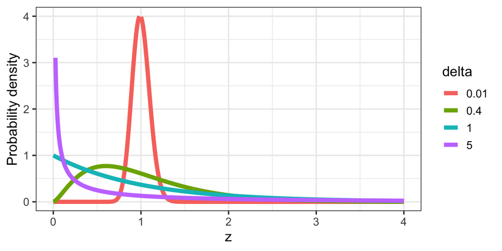

# Gamma frailty distribution

The Laplace transform is then given as

$$\begin{align*}
\mathcal{L}(c) &= (1+\delta c)^{-1/\delta}
\end{align*}$$

We can now express the population survival as

$$\begin{align*}
S(t) &= \mathcal{L}(A(t)) = (1+\delta A(t))^{-1/\delta}
\end{align*}$$

and the population hazard rate as

$$\begin{align*}
\mu(t) &= -\alpha(t) \frac{\mathcal{L}'(A(t))}{\mathcal{L}(A(t))} = \frac{\alpha(t)}{1+\delta A(t)}
\end{align*}$$

When $\delta \downarrow 0$, the variability of the frailty distribution tends to 0 and $\mu(t) \approx \alpha(t)$. As the variance $\delta$ increases, the population hazard function assumes the frailty shape of a hazard function that is “dragged down” (see next slide).

# Gamma frailty distribution: population hazard rate

Population hazard rate $\mu(t)$ when $\alpha(t) = 1$ and $\alpha(t) = t^2$, for different values of $\delta$.

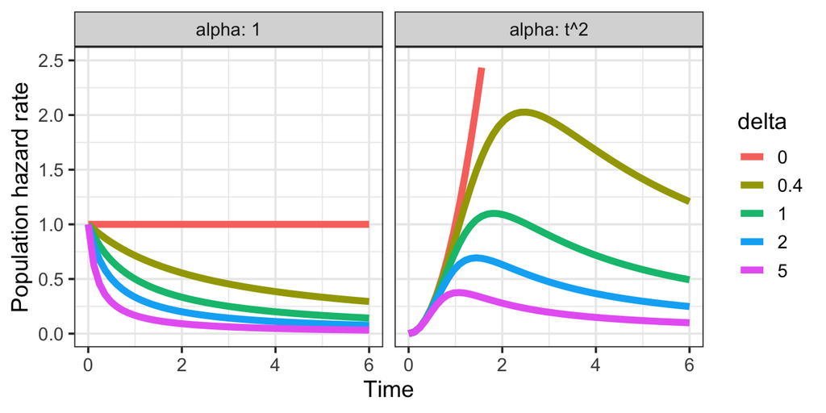

When $\delta = 0$ there is no frailty effect and $\mu(t) = \alpha(t)$.

The presence of frailty ($\delta>0$) pulls the population hazard rate down, transforming even an ever-increasing basic rate ($\alpha(t) =t^2$, right panel) into a quite different shape.

This can be explained by “frail” individuals (high levels of $Z$) developing the event earlier, leaving a population consisting of “less frail” individuals (low levels of $Z$). Intuitively, does this agree with the fact that $\mu(t) = \alpha(t) E(Z|T>t)$?

If frailty is present, the observed population hazard rate does not say anything about the development at the individual level, but it is mixed up with selection effects.

# Gamma frailty distribution: effect on hazard ratio

Assume that the basic hazard rates in two risk groups are $\alpha(t)$ and $r \alpha(t)$ with $r>1$.

Assume that the frailty variables have the same gamma distribution with variance $\delta$ in both groups (ie, we assume proportionality of the hazards to hold at the individual level).

The population hazard ratio is

$$\begin{align*}
\frac{\mu_2(t)}{\mu_1(t)} &=r \frac{1+\delta A(t)}{1+r\delta A(t)}
\end{align*}$$

This expression is decreasing in $t$ and if $A(t) \rightarrow \infty$ when $t$ increases then the ratio approaches 1.

Typically, if we assume proportionality at the level of the individual hazards, that proportionality will disappear at the population level.

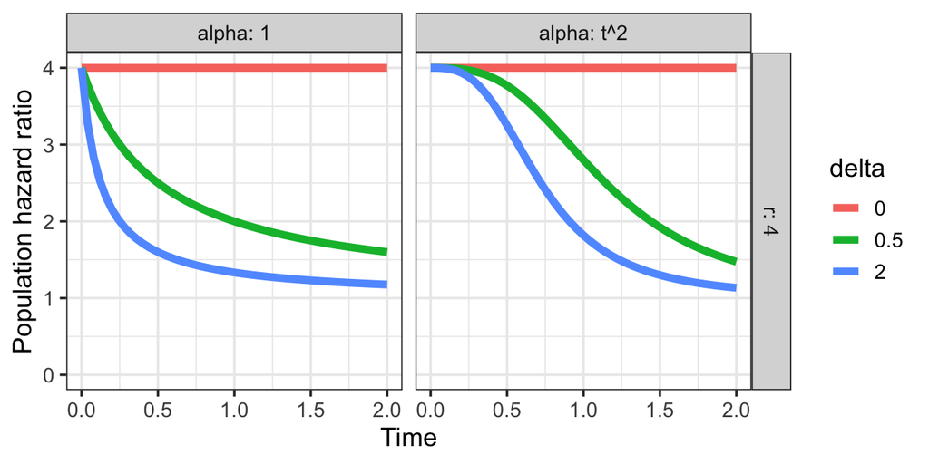

In this case, the observed hazard ratio will be decreasing due to frailty but $\frac{\mu_2(t)}{\mu_1(t)}>1$. With other frailty distributions it may cross below one. With the stable frailty distribution, on the other hand, proportionality of the hazards holds at the individual and at the population level (but the proportionality constants are different); see ABG 6.5.

# Identifiability

When there is at most one event for each individual, frailty models will often not be *identifiable*.

Observing a population hazard ratio like the ones we saw earlier is compatible with two explanations:

1. The proportional hazard assumption holds in the conditional model ($\alpha_2(t|Z) = Zr\alpha_1(t)$). What we observe is a result of unobserved heterogeneity (frailty).
2. There is no heterogeneity. What we observe is the time-dependent effect of the covariate ($\alpha_2(t) = r(t) \alpha_1(t)$).

Based on the (observed) population hazard rates alone, it is impossible to decide whether frailty is present or not. To fit a frailty model, we would first need to assume a conditional proportional hazards assumption and then select a parametric model class for the basic hazard rate $\alpha(t)$.

This identifiability problem can be generally avoided in the multivariate case (clustered or recurrent events).

# Multivariate frailty models

We now consider grouped outcomes, where the groups can be defined in terms of

1. *Clusters*, when several units that may fail are collected in a cluster;
2. *Recurrent events*, when several successive events of the same type are registered for each individual.

For grouped outcomes, we can consider *shared frailty models*, ie the same frailty is shared by all the survival time of an individual or cluster $i$.

Frailty measures the specific risk level for a cluster or an individual, and given $Z$ the survival times are independent. We assume the proportional frailty model $\alpha(t|Z_i)=Z_i\alpha(t)$.

# Notation

Consider $m$ independent clusters or individuals with index $i$. Let the actual event time be $T_{ij}$ and let the observed (possibly right-censored) times be $\tilde{T}_{ij}$ for the $j=1,\ldots,n_i$ cluster units or inter-event times.

The basic rate $\alpha(t)$ is a fixed function and assumed to be the same for all $i$, but each cluster or individual has a separate independent frailty $Z_i$ with $\boldsymbol{Z}=\{Z_1, \ldots, Z_i, \ldots, Z_m\}$. All of the frailty variables are identically distributed.

Lastly, let $D_{ij}$ be binary variables that are 1 if the event time is uncensored and are 0 if censored. Let $D_{i\bullet}=\sum_j D_{ij}$, which is the number of events for cluster or individual $i$.

# Conditional likelihood

Assume that, conditional on $\boldsymbol{Z}=\boldsymbol{z}$, censoring is independent and noninformative of $\boldsymbol{z}$ (ABGK Assumption IX.3.1 and IX.3.2).

For each cluster of individual $i$, $\tilde{T}_{ij}$ and $D_{ij}$ are combined into the history $H_i=(\tilde{T}_{i1}, D_{i1}, \ldots, \tilde{T}_{in_i}, D_{in_i})$. Let $P(H_i)$ denote the joint distribution of $H_i$. Conditional with respect to $Z_i$, the event times are independent with intensity $Z_i\alpha(t)$.

ABG argue that their conditional likelihood $P(H_i|Z_i)$ can be deduced (sic) from

$$\begin{align}
L_i(\theta) = \alpha(\tilde{T}_i;\theta)^{D_i}\exp\left\{- \int_0^{\tilde{T}_i} \alpha(t;\theta)dt\right\}
\end{align}$$

as

$$\begin{align*}
P(H_i|Z_i) &= \prod_{j=1}^{n_i} \left(\left(Z_i\alpha(\tilde{T}_{ij})\right)^{D_{ij}}\exp(-Z_i A(\tilde{T}_{ij}))\right)
\end{align*}$$

where $\theta$ is dropped from $\alpha$ to simplify notation.

# Unconditional and total likelihood

The unconditional likelihood follows by taking the expectation with respect to frailty variable $Z$

$$\begin{align*}
P(H_i) &= E_{Z_i}(P(H_i|Z_i)) \\ &= \prod_{j=1}^{n_i} \left(\alpha(\tilde{T}_{ij})^{D_{ij}}\right)
E_{Z_i}\left(Z_i^{D_{i\bullet}}\exp(-Z_i V_i)\right)
\end{align*}$$

where $V_i=\sum_j A(\tilde{T}_{ij})$.

Applying the fact that the $r\text{th}$ order derivative of a Laplace transform is $\mathcal{L}^{(r)}(c)=(-1)^rE(Z^r\exp(-cZ))$, we can now write the contribtion of individual or cluster $i$ as

$$\begin{align*}
P(H_i) &= \prod_{j=1}^{n_i} \left(\alpha(\tilde{T}_{ij})^{D_{ij}}\right)
(-1)^{D_{i\bullet}}\mathcal{L}^{(D_{i\bullet})}(V_i)
\end{align*}$$

and the total log-likelihood of $m$ conditionally independent individuals or clusters as

$$\begin{align*}
\log L &= \sum_{i=1}^m\left( \sum_{j=1}^{n_i} D_{ij}\log\left(\alpha(\tilde{T}_{ij})\right) +
\log\left((-1)^{D_{i\bullet}}\mathcal{L}^{(D_{i\bullet})}(V_i)\right) \right)
\end{align*}$$

Predicted frailty for cluster or individual $i$ is $\hat{Z_i}=E(Z_i|H_i) = -\frac{\mathcal{L}^{(D_{i\bullet}+1)}(V_i)}{\mathcal{L}^{(D_{i\bullet})}(V_i)}$ (see ABG 7.2.3).

# Frailty and counting processes

Consider a multivariate counting process $\boldsymbol N = (N_i(t), i=1, \ldots, m)$, where each $N_i$ can have more than one jump, with individual intensity processes

$$\lambda^*_i(t)=Z_iY_i(t)\alpha(t)$$

$\boldsymbol Y=(Y_i(t), i=1, \ldots, m)$ are observable predictable processes such that, in case of *recurrent events*, $Y_i(t) = 1$ as long as the process is observed and 0 afterwards, and, in case of *clustered data*, $Y_i(t)$ represents the number of units still at risk.

The complete but unobservable data consists of the triplet $\{\boldsymbol Z, \boldsymbol N, \boldsymbol Y \}$, while the incomplete but observable data consists of $\{\boldsymbol N, \boldsymbol Y \}$.

The intensity processes $\lambda^*_i(t)$ are relative to the history $\mathcal{G}_{t} = \sigma\left\{\boldsymbol Z, \boldsymbol N(u), \boldsymbol Y(u+): 0 \le u \le t \right\}$ partly generated by unobserved quantities. When calculating likelihood functions, we have to consider intensities wrt the smaller history generated by the observed data: $\mathcal{F}_{t} = \sigma\left\{\boldsymbol N(u), \boldsymbol Y(u+): 0 \le u \le t \right\}$, with $\mathcal{F}_{t} \subset \mathcal{G}_{t}$.

# Observed intensity processes

The observed intensity process $\lambda_i(t)$ for the individual $N_i(t)$ is given by the innovation theorem

$$\begin{align}
\lambda_i(t) &= E(E(dN_i(t)|\mathcal{G}_{t^-})|\mathcal{F}_{t^-}) \\
&= E(\lambda^*_i(t)|\mathcal{F}_{t^-}) \\
&= Y_i(t)\alpha(t)E(Z_i | \mathcal{F}_{t^-})
\end{align}$$

The observed intensity process can be written as (ABG 7.3)

$$\lambda_i(t) = Y_i(t)\alpha(t) \frac{-\mathcal{L}^{(N_i(t^-)+1)}\left(\int_0^{t^-}Y_i(s)\alpha(s)ds\right)}{\mathcal{L}^{(N_i(t^-))}\left(\int_0^{t^-}Y_i(s)\alpha(s)ds\right)}$$

If the $Z_i$ are unit-mean–Gamma distributed then

$$\lambda_i(t) = Y_i(t)\alpha(t) \frac{1+\delta N_i(t^-)}{1+\delta\int_0^{t^-}Y_i(s)\alpha(s)ds}$$

# Likelihood in counting process form

If we specify a parametric class for $\alpha(t)$, we can plug $\lambda_i(t)$ into the log-likelihood

$$\log L = \sum_{i=1}^m \int_0^{\tau} \log\lambda_i(s)dN_i(s)-\int_0^{\tau} \lambda_{\bullet}(s;) ds$$

Estimates may be found by maximising the likelihood directly and the same counting process tools we saw last time can be used for proving large sample properties of the maximum likelihood estimators.

If, conditional on $\boldsymbol{Z}=\boldsymbol{z}$, censoring is also noninformative on $\theta$, then the log-likelihood above is a full marginal log-likelihood for $\alpha(t)$. Otherwise, it’s a partial marginal log-likelihood.

In other words, the log-likelihood above is either the full or partial log-likelihood for $\theta$ based on $\{\boldsymbol N$, $\boldsymbol Y\}$, ie in the marginal/incomplete data experiment when $\boldsymbol Z$ is not observed.

Further details are in ABGK IX.2, IX.3, IX.4.1.

# Software implementation

Fully parametric frailty models are available here:

- R: `parfm`, `frailtyEM`, `frailtypack`, `rstpm2`
- Stata: `streg`, `merlin`
- SAS: `proc nlmixed`

# Example, Gamma-Weibull model

Using the `parfm` package.

```r
library(parfm)

bc <- read.csv("/Users/anddis/OneDrive - KI.SE/other/teaching/tsa_2022/bc.csv")
bc$id <- 1:nrow(bc)
head(bc)
```

```
##   age smoking dietfat     t dead id
## 1  30       1   4.919 14.20    0  1
## 2  50       0   4.437  8.21    1  2
## 3  47       0   5.850  5.64    1  3
## 4  49       1   5.149  4.42    1  4
## 5  52       1   4.363  2.81    1  5
## 6  29       0   6.153 35.00    0  6
```

```r
frailty.mod <- parfm(Surv(t, dead) ~ 1,
                     dist = "weibull",
                     frailty = "gamma",
                     cluster = "id",
                     data = bc)
frailty.mod
```

```
##
## Frailty distribution: gamma
## Baseline hazard distribution: Weibull
## Loglikelihood: -228.4
##
##        ESTIMATE    SE
## theta     2.521 1.465
## rho       1.307 0.371
## lambda    0.094 0.033
```

`Z.hat`, $\hat{Z_i}= -\frac{\mathcal{L'}(A(t))}{\mathcal{L}(A(t))}$

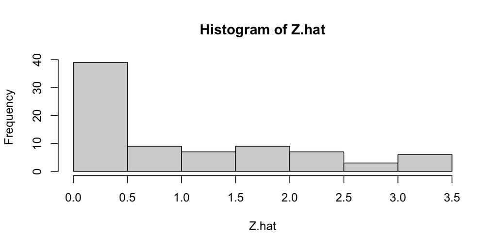

```r
Z.hat <- predict(frailty.mod)
hist(Z.hat)
```

`cond.haz`, $\alpha(t| Z) = Z \alpha(t)$

```r
timeseq <- seq(0, max(bc$t), length = 501)
alpha.hat <- hWeibull(timeseq,
                      frailty.mod["lambda", 1],
                      frailty.mod["rho", 1])
cond.haz <- outer(alpha.hat, Z.hat)
```

`pop.haz`, $\mu(t) = \frac{\alpha(t)}{1+\theta A(t)}$

```r
mu.hat <- function(t, lambda, rho, theta) {
  (hWeibull(t, lambda, rho)) /
    (1 + frailty.mod["theta", 1] * HWeibull(t, lambda, rho))
}

pop.haz <- mu.hat(timeseq,
                  frailty.mod["lambda", 1],
                  frailty.mod["rho", 1],
                  frailty.mod["theta", 1])
```

`pop.haz.empirical`, $\mu(t) = \alpha(t) \bar Z_{T>t}$

```r
pop.haz.empirical <- sapply(
  timeseq,
  function(x) mean(Z.hat[bc$id[bc$t > x]])
) *  alpha.hat
```

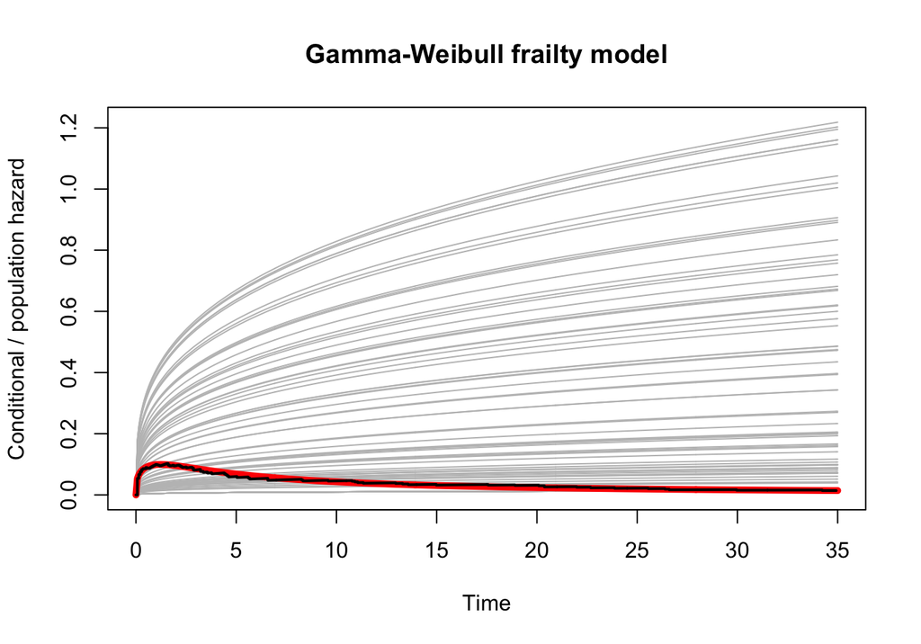

```r
matplot(timeseq, cond.haz, type = "l", col = "grey75", lty = 1,
        ylab = "Conditional / population hazard", xlab = "Time",
        main = "Gamma-Weibull frailty model")
lines(timeseq, pop.haz, col = "red", lwd = 5)
lines(timeseq, pop.haz.empirical, type = "s", lwd = 2)
```